# Phylogenetic positions of three recently described dragon species

Access files on [Github](https://github.com/ameliems99/Dragon_Phylogeny)

Amelie Mahrt-Smith, Queen’s University

## Dragon Species

This report analyzes the phylogenetic relationships between three recently described dragon species, the *Red serpent* (Windseeker, 2021), the *Snowheart* (fanTASyartistry, 2022), and the *Steel boss* (ERA7, 2022), with the known dragon species previously described by [Colautti (2009)](https://gizmodo.com/the-evolutionary-history-of-dragons-illustrated-by-a-s-5936427).

The *R. serpent* dragon was discovered in the United States of America, and its likeness was captured by user ‘Windseeker’ on [DeviantArt](https://www.deviantart.com/windseeker/art/Red-Serpent-893955932). Curiously, the *R. serpent* has been observed to fly when under stress, despite having neither wings nor limbs.

[figure not shown]

**Figure 1.** The *Red serpent* dragon engaging in defensive behaviour.

The *Snowheart* dragon was discovered recently in the United Kingdom by DeviantArt user ‘fanTASyartistry’, who has also provided a visual reference of the species on [DeviantArt](https://www.deviantart.com/fantasyartistry/art/Snowheart-Dragon-commission-907603851). This dragon is unique in that it does not breathe fire, but instead appears to breathe some molten chemcial compound that immediately crystallizes upon exposure to the atmosphere. Analyses on these crystalline structures are forthcoming.

[figure not shown]

**Figure 2.** A rendering of the *Snowheart* dragon.

Finally, the *S. boss* dragon was seen in Russia earlier this year. The discoverer, user ‘ERA7’ on [DeviantArt](https://www.deviantart.com/era7/art/Steel-Dragon-Boss-907575223), observed this dangerous creature from a distance. This species has a rare 2-headed phenotype, a trait which is not encoded in this report, so future analyses may find a different evolutionary origin of this species than proposed here.

[figure not shown]

**Figure 3.** The *Steel boss* dragon from afar.

## Analysis

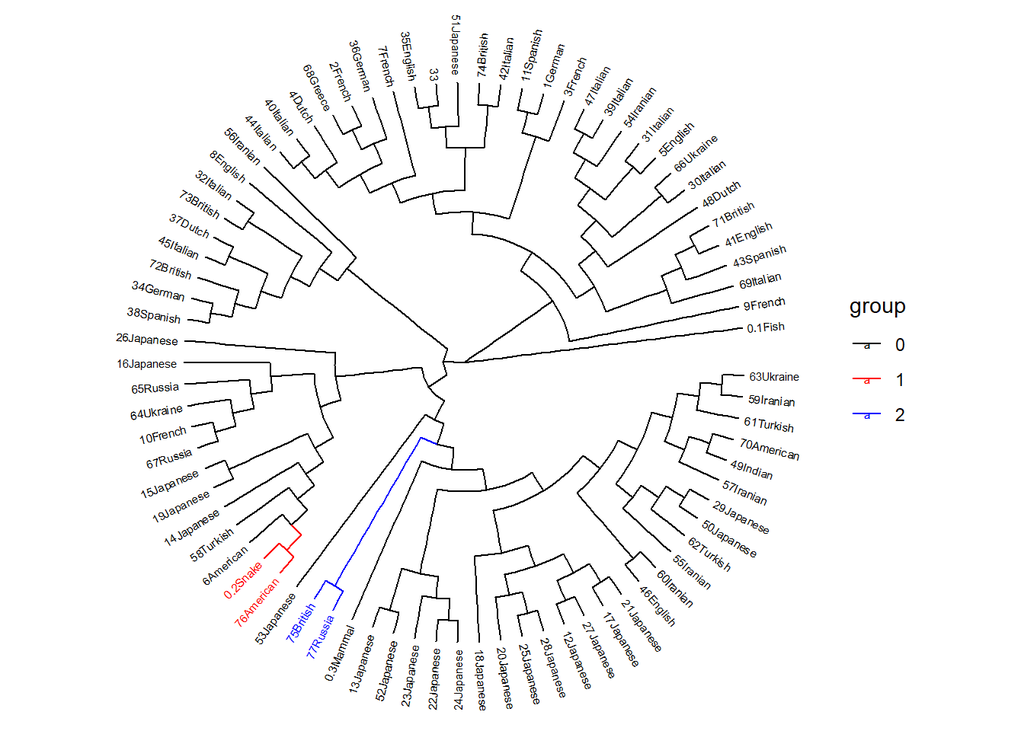

```r
library(ape)
library(dplyr)
library(ggtree)

DragonsNexus <- c(read.nexus.data("input/DragonMatrix.nex"), read.nexus.data("input/A7_MAHRTSMITH_AMELIE_DragonAppend.nex")) #import original and appendment data into single list object

WeightsDat <- read.csv("input/Weights.csv")  #import weighting data
WeightsVec <- paste0(WeightsDat$Weight, collapse = "") %>% strsplit(split = "") %>% unlist() #vector of weights
WeightsNum <- rep(NA, length(WeightsVec)) #empty vector for storing data
for (i in 1:length(WeightsVec)){
  if (WeightsVec[i] %in% c(0:9)) {
    WeightsNum[i] <- as.numeric(WeightsVec[i])  #if weight already a digit, keep numbers as-is
  } else {
    WeightsNum[i] <- as.numeric(which(LETTERS == WeightsVec[i]) + 9)  #replace letter weights with a corresponding number from 10-35
  }
}

WtDragonNex <- DragonsNexus
for (i in 1:length(WtDragonNex)) {
  WtDragonNex[[i]] <- paste(as.numeric(WtDragonNex[[i]])*WeightsNum) #multiply the binary trait values by the weighted values
}
WtDragonDF <- data.frame(matrix(unlist(WtDragonNex), ncol = length(WtDragonNex[[1]]), byrow = TRUE))  #convert to data frame
row.names(WtDragonDF) <- names(DragonsNexus)  #keep original row names

WtDragonDist <- dist(WtDragonDF, method = 'euclidean')  #compute evo distances
WtDragonTree <- fastme.bal(WtDragonDist)  #minimum evolution tree
WtDragonTree$tip.label <- gsub("([^X]+)X*", "\\1", WtDragonTree$tip.label)  #remove X's from tip labels
WtDragonTree <- groupClade(WtDragonTree, .node = c(91, 123))  #highlight new species

ggtree(WtDragonTree, layout = 'circular', branch.length = 'none', aes(colour = group)) +
    geom_tiplab(size = 2, hjust = -.1) +
    scale_colour_manual(values = c("black", "red", "blue"))  #plot phylogenetic tree
```

**Figure 4**. The evolutionary origins of the *Red Serpent*, the *Snowheart*, and the *Steel Boss* dragons.

It appears that the *Snowheart* and *S. boss* dragons (75British and 77Russia, respectively) arose from the same lineage, highlighted in blue in Fig. 4. The *R. serpent* dragon (76American), highlighted in red (Fig.4), is unsurprisingly related to the snake. There is therefore exciting potential to elucidate the genetic basis of defensive flying without wings in the *R. serpent* lineage, if we could figure out how to get close enough to take samples.